# ANN (ARTIFICIAL NEURAL NETWORK)

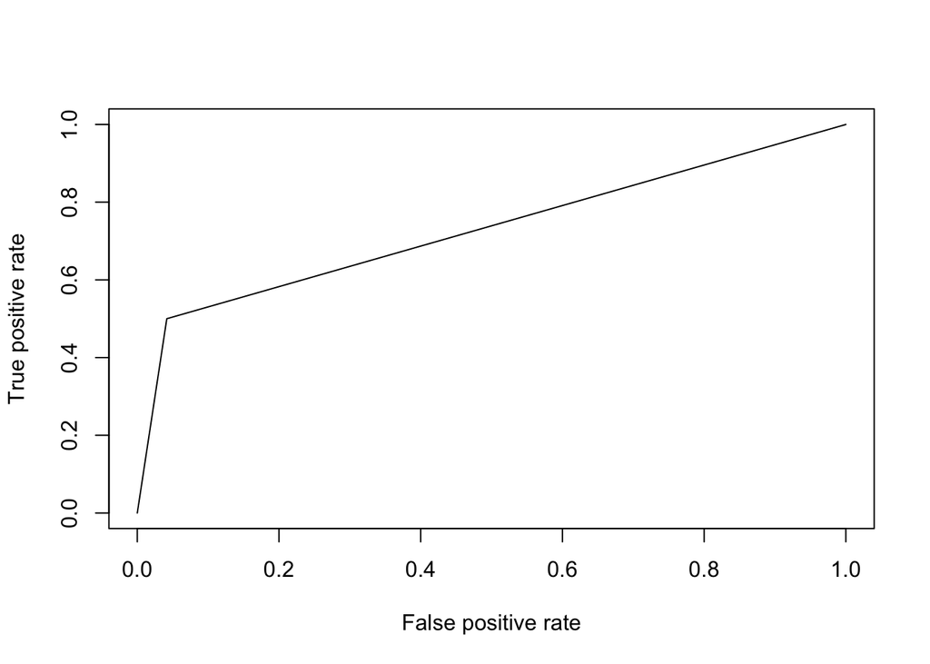

```r
plot(perf)
```

Creo otro clasificador, esta vez con una funcion de activación diferente, com menos capas pero con más neuronas en ellas, 100 iteraciones y un aprendizaje autimatico.

```r
classifier1 = h2o.deeplearning(y = "R",
                               training_frame = as.h2o(training_set),
                               activation = "Tanh",
                               hidden = c(500, 500),
                               epochs = 100,
                               train_samples_per_iteration = -2,
                               adaptive_rate = TRUE)
prob_pred1 = h2o.predict(classifier1,
                        newdata = as.h2o(testing_set[, -61]))
y_pred1 = (prob_pred1 > 0.8)
y_pred1 = as.vector(y_pred1)
```

```r
cm1 = table(testing_set[, 61], y_pred1)
```

El resultado ahora es un poco mejor, obtenemos que acierta en su calsificación en un 80.76%

```r
cm1
```

```
##    y_pred1
##      0  1
##   0 23  1
##   1  9 19
```

```r
pred1 <- prediction(as.numeric(y_pred1), as.numeric(testing_set[, 61]))
perf1 <- performance(pred1, "tpr", "fpr")
```

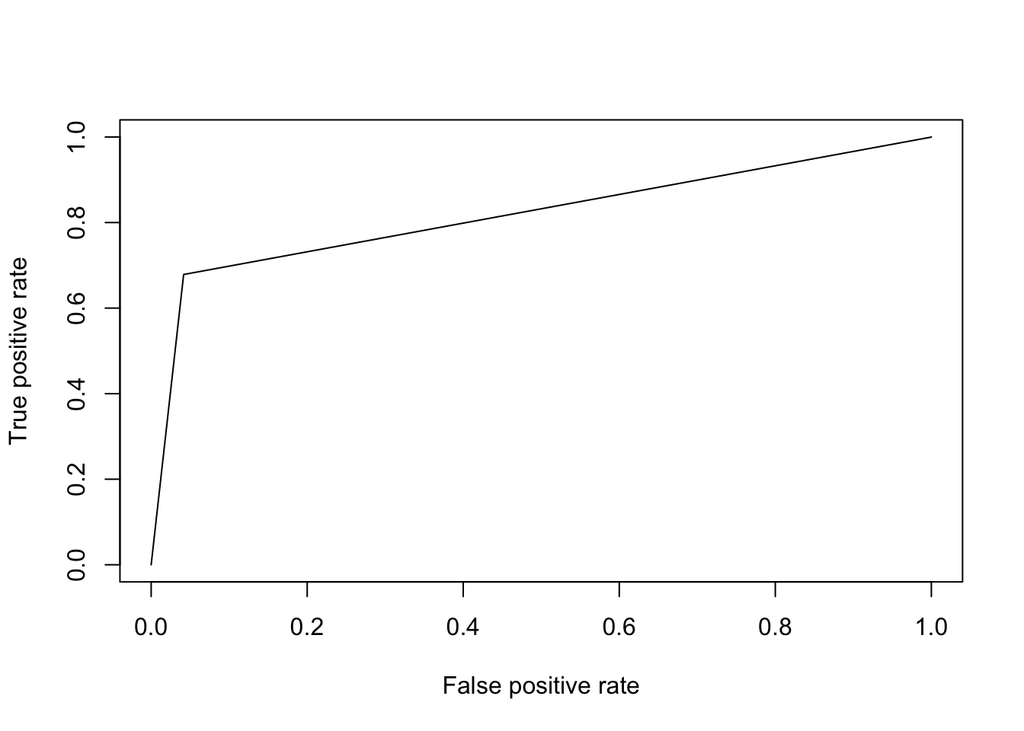

```r
plot(perf1)
```

Y por último, genero otro calsificador con 3 capas de 500 neuronas cada una, 500 iteraciones y ne este caso le programo yo lo rapido que quiero que aprenda.

```r
classifier2 = h2o.deeplearning(y = "R",
                               training_frame = as.h2o(training_set),
                               activation = "Rectifier",
                               hidden = c(500, 500, 500),
                               epochs = 500,
                               train_samples_per_iteration = -2,
                               adaptive_rate = FALSE,
                               rate = 0.00001, # Lo rápido que aprende por iteración
                               nesterov_accelerated_gradient = TRUE)
prob_pred2 = h2o.predict(classifier2,
                         newdata = as.h2o(testing_set[, -61]))
y_pred2 = (prob_pred2 > 0.8)
y_pred2 = as.vector(y_pred2)
```

```r
cm2 = table(testing_set[, 61], y_pred2)
```

El resultado es prácticamente identico al anterior. Posiblemente nos encontremos que este sesgado.

```r
cm2
```

```
##    y_pred2
##      0  1
##   0 24  0
##   1 11 17
```

```r
pred2 <- prediction(as.numeric(y_pred2), as.numeric(testing_set[, 61]))
perf2 <- performance(pred2, "tpr", "fpr")
```

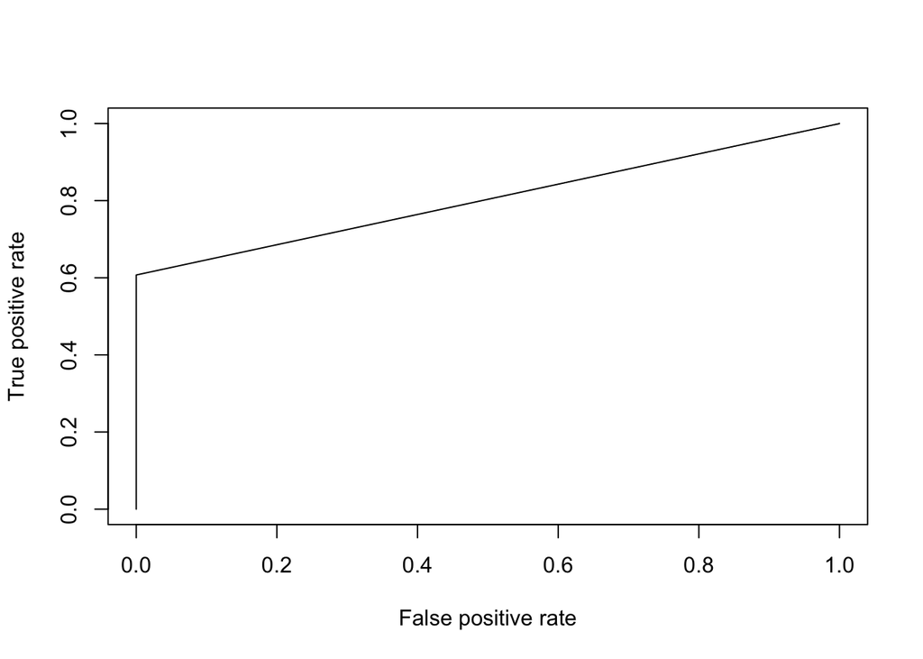

```r
plot(perf2)
```

Cerramos la libreria.

```r
h2o.shutdown()
```

```
## Are you sure you want to shutdown the H2O instance running at http://localhost:54321/ (Y/N)?
```

```
## [1] TRUE
```

Como conclusión pordemos decir que las redes neuronales han tenido una buena clasificacion, con un porcentaje de acierto muy alto. El problema es que la muestra de observaciones es muy pequeña, por lo que es posible que hallamos podido tener cierto sesgo, dependiendo del numero de capas utilizadas o de neuronas. Provocando un sobre aprendizaje.